# rethinkingINLA_HW5

Ania Kawiecki

8/3/2020

[Statistical rethinking homework solutions](https://github.com/rmcelreath/statrethinking_winter2019/tree/master/homework)

[INLA book](https://becarioprecario.bitbucket.io/inla-gitbook/ch-intro.html)

```r
library(tidyverse)
library(rethinking)
library(dagitty)
library(INLA)
library(knitr)
library(stringr)
```

# HOMEWORK 5

## 1.

Consider the data (Wines2012) data table.These data are expert ratings of 20 different French and American wines by 9 different French and American judges. Your goal is to model score, the subjective rating assigned by each judge to each wine. I recommend standardizing it.

In this first problem, consider only variation among judges and wines. Construct index variables of judge and wine and then use these index variables to construct a linear regression model. Justify your priors. You should end up with 9 judge parameters and 20 wine parameters. Use ulam instead of quap to build this model, and be sure to check the chains for convergence. If you’d rather build the model directly in Stan or PyMC3, go ahead. I just want you to use Hamiltonian Monte Carlo instead of quadratic approximation. How do you interpret the variation among individual judges and individual wines? Do you notice any patterns, just by plotting the differences? Which judges gave the highest/lowest ratings? Which wines were rated worst/ best on average?

```r
library(rethinking)
data(Wines2012)
d <- Wines2012

dat_list <- list(
    S = standardize(d$score),
    jid = as.integer(d$judge),
    wid = as.integer(d$wine)
)

str(dat_list)
```

```
## List of 3
##  $ S  : num [1:180] -1.5766 -0.4505 -0.0751 0.3003 -2.3274 ...
##   ..- attr(*, "scaled:center")= num 14.2
##   ..- attr(*, "scaled:scale")= num 2.66
##  $ jid: int [1:180] 4 4 4 4 4 4 4 4 4 4 ...
##  $ wid: int [1:180] 1 3 5 7 9 11 13 15 17 19 ...
```

The model is straightforward. The only issue is the priors. Since I’ve standardized the outcome, we can use the ordinary N(0,0.5) prior from the examples in the text with standardized outcomes. Then the prior outcomes will stay largely within the possible outcome space. A bit more regularization than that wouldn’t be a bad idea either.

### 1. rethinking

```r
#How do you interpret the variation among individual judges and indi- vidual wines?
#Do you notice any patterns, just by plotting the differences? Which judges gave the highest/lowest ratings? Which wines were rated worst/ best on average?

m1 <- ulam(
  alist(
    S ~ dnorm(mu, sigma),
    mu <- a[jid] + b[wid],
    a[jid] ~ dnorm(0, 0.5),
    b[wid] ~ dnorm(0, 0.5),
    sigma ~dexp(1)

  ), data=dat_list, chains=4 , cores=4)
```

```
## Trying to compile a simple C file
```

[output not shown]

```r
precis(m1, 2)
```

```
##               mean         sd        5.5%       94.5%    n_eff     Rhat4
## a[1]  -0.278058356 0.19335742 -0.58335269  0.03433134 1828.875 0.9987144
## a[2]   0.210837831 0.19325974 -0.10564655  0.51381639 1769.881 0.9995694
## a[3]   0.203288242 0.20309618 -0.12710381  0.52271753 2012.137 0.9991544
## a[4]  -0.542033853 0.19644229 -0.86479650 -0.23905876 2022.186 0.9999361
## a[5]   0.796408712 0.20168528  0.47542737  1.11749267 2157.997 0.9999550
## a[6]   0.474388360 0.19596218  0.16098610  0.79171059 1762.298 0.9996533
## a[7]   0.128884427 0.19620619 -0.18558687  0.44920310 1810.069 0.9987258
## a[8]  -0.659172547 0.19529801 -0.96804052 -0.35441961 2283.619 1.0001619
## a[9]  -0.348798903 0.19903849 -0.66264715 -0.03844885 2144.659 0.9992943
## b[1]   0.115841169 0.26074556 -0.30866980  0.52235618 2511.549 0.9992723
## b[2]   0.091203069 0.25805203 -0.31787544  0.50172056 2879.831 0.9990262
## b[3]   0.229985953 0.26637248 -0.19359916  0.65356918 2565.388 0.9997264
## b[4]   0.468546836 0.25982124  0.04484775  0.87710698 2538.513 0.9993143
## b[5]  -0.110288854 0.26411530 -0.53701262  0.32233215 2892.091 0.9992179
## b[6]  -0.305355843 0.25212938 -0.69765739  0.09937410 2588.933 0.9986413
## b[7]   0.249845395 0.25393237 -0.16328060  0.65219503 2898.759 0.9988886
## b[8]   0.226292982 0.25742933 -0.19539028  0.64893579 1984.411 0.9997763
## b[9]   0.069120792 0.26342935 -0.35492083  0.48861851 2744.242 0.9986944
## b[10]  0.098462611 0.25850667 -0.31538115  0.50370156 2475.161 0.9988858
## b[11] -0.011369352 0.24068805 -0.40508502  0.35940500 2422.681 0.9995702
## b[12] -0.026682631 0.24589824 -0.42733354  0.37711719 2333.619 0.9997247
## b[13] -0.085385963 0.25348263 -0.47526604  0.32306722 2285.685 0.9991116
## b[14]  0.003688317 0.26438744 -0.42396125  0.41482619 2784.935 0.9982459
## b[15] -0.183412572 0.26388828 -0.59715178  0.23940769 3341.421 0.9992812
## b[16] -0.167388521 0.26566840 -0.60461182  0.25403496 2292.277 1.0000525
## b[17] -0.116620061 0.25659478 -0.53304768  0.29357030 2710.961 0.9988988
## b[18] -0.723146241 0.25171483 -1.12808551 -0.31537683 3063.858 1.0003985
## b[19] -0.132633374 0.26096624 -0.55200073  0.27402799 2597.315 0.9988331
## b[20]  0.324640909 0.25553702 -0.09099300  0.73006953 2393.610 0.9990022
## sigma  0.846605986 0.04718222  0.77508877  0.92262260 3036.642 0.9985200
```

```
## [1] 1000
## [1] 1
## [1] 1000
```

```
## Waiting to draw page 2 of 2
```

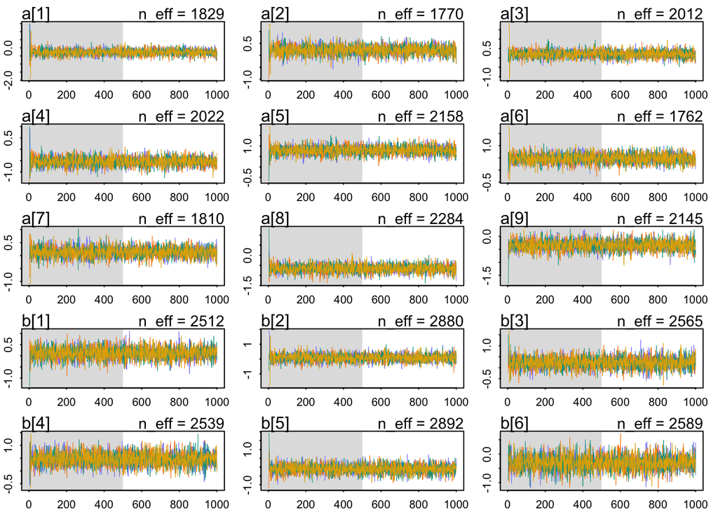

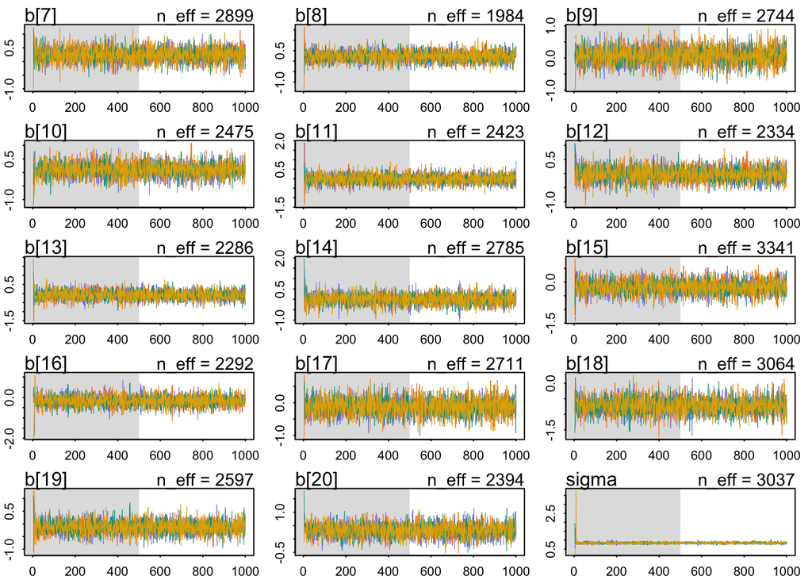

```r
traceplot(m1)
```

[figure not shown]

```r
plot(precis(m1, 2))
```

### 1. INLA

In order to code a separate intercept for each judge and wine, we need to reformat the data so that there are separate variables for each intercept, with 1s for a given value of the variable we are basing the intercept on and NAs for all other values.

```r
d.i <- d %>%
  mutate(S = standardize(d$score),
    jid = paste("j",as.integer(d$judge), sep= "."),
    wid =  paste("w",as.integer(d$wine), sep= "."),
    j.value= 1,
    w.value= 1) %>%
  spread(jid, j.value) %>%
  spread(wid, w.value)

j <- paste("j", 1:9, sep=".")

w <- paste("w", 1:20, sep=".")

est <- c(j,w)

m1.i<- inla(S~ -1 +j.1+ j.2+j.3+j.4+j.5+j.6+j.7+j.8+j.9+
                          w.1+w.2+ w.3+w.4+w.5+w.6+w.7+w.8+w.9+w.10+w.11+w.12+w.13+w.14+w.15+ w.16+w.17+ w.18+w.19+w.20, data= d.i,
                        control.fixed = list(
        mean= 0,
        prec= 0.5),
        control.compute = list(dic=TRUE, waic= TRUE)
)

summary(m1.i )
```

```
##
## Call:
##    c("inla(formula = S ~ -1 + j.1 + j.2 + j.3 + j.4 + j.5 + j.6 + j.7 + ",
##    " j.8 + j.9 + w.1 + w.2 + w.3 + w.4 + w.5 + w.6 + w.7 + w.8 + ", " w.9
##    + w.10 + w.11 + w.12 + w.13 + w.14 + w.15 + w.16 + w.17 + ", " w.18 +
##    w.19 + w.20, data = d.i, control.compute = list(dic = TRUE, ", " waic =
##    TRUE), control.fixed = list(mean = 0, prec = 0.5))" )
## Time used:
##     Pre = 3.4, Running = 0.296, Post = 0.429, Total = 4.12
## Fixed effects:
##        mean    sd 0.025quant 0.5quant 0.975quant   mode kld
## j.1  -0.313 0.320     -0.941   -0.313      0.314 -0.313   0
## j.2   0.240 0.320     -0.388    0.240      0.867  0.240   0
## j.3   0.230 0.320     -0.397    0.230      0.858  0.230   0
## j.4  -0.608 0.320     -1.236   -0.608      0.019 -0.608   0
## j.5   0.894 0.320      0.266    0.894      1.522  0.894   0
## j.6   0.535 0.320     -0.093    0.535      1.162  0.535   0
## j.7   0.147 0.320     -0.480    0.147      0.775  0.148   0
## j.8  -0.737 0.320     -1.365   -0.738     -0.110 -0.738   0
## j.9  -0.387 0.320     -1.015   -0.387      0.240 -0.387   0
## w.1   0.148 0.377     -0.593    0.148      0.889  0.148   0
## w.2   0.108 0.377     -0.633    0.108      0.849  0.108   0
## w.3   0.289 0.377     -0.452    0.289      1.029  0.289   0
## w.4   0.590 0.377     -0.152    0.590      1.330  0.590   0
## w.5  -0.132 0.377     -0.873   -0.132      0.608 -0.132   0
## w.6  -0.393 0.377     -1.134   -0.393      0.348 -0.393   0
## w.7   0.309 0.377     -0.432    0.309      1.049  0.309   0
## w.8   0.289 0.377     -0.452    0.289      1.029  0.289   0
## w.9   0.088 0.377     -0.653    0.088      0.829  0.088   0
## w.10  0.128 0.377     -0.613    0.128      0.869  0.128   0
## w.11 -0.012 0.377     -0.753   -0.012      0.728 -0.012   0
## w.12 -0.032 0.377     -0.773   -0.032      0.708 -0.032   0
## w.13 -0.112 0.377     -0.853   -0.112      0.628 -0.112   0
## w.14  0.008 0.377     -0.733    0.008      0.748  0.008   0
## w.15 -0.233 0.377     -0.974   -0.233      0.508 -0.233   0
## w.16 -0.213 0.377     -0.954   -0.213      0.528 -0.213   0
## w.17 -0.152 0.377     -0.893   -0.152      0.588 -0.152   0
## w.18 -0.914 0.377     -1.655   -0.915     -0.174 -0.915   0
## w.19 -0.172 0.377     -0.913   -0.172      0.568 -0.173   0
## w.20  0.409 0.377     -0.332    0.409      1.149  0.409   0
##
## Model hyperparameters:
##                                         mean    sd 0.025quant 0.5quant
## Precision for the Gaussian observations 1.41 0.159       1.11     1.40
##                                         0.975quant mode
## Precision for the Gaussian observations       1.74 1.39
##
## Expected number of effective parameters(stdev): 27.12(0.101)
## Number of equivalent replicates : 6.64
##
## Deviance Information Criterion (DIC) ...............: 481.08
## Deviance Information Criterion (DIC, saturated) ....: 211.59
## Effective number of parameters .....................: 28.36
##
## Watanabe-Akaike information criterion (WAIC) ...: 482.39
## Effective number of parameters .................: 26.24
##
## Marginal log-Likelihood:  -273.56
## Posterior marginals for the linear predictor and
##  the fitted values are computed
```

```r
## Pull out summaries from the model object
m1.i.sum <- summary(m1.i)

## Summarise results
m1.i.df  <- data.frame(mean = m1.i.sum$fixed[,"mean"],
                       lower = m1.i.sum$fixed[,"0.025quant"],
                       upper = m1.i.sum$fixed[,"0.975quant"],
                       stringsAsFactors = FALSE)

mi.i.df <- bind_cols(as.factor(est), m1.i.df)
```

```
## * NA -> ...1
```

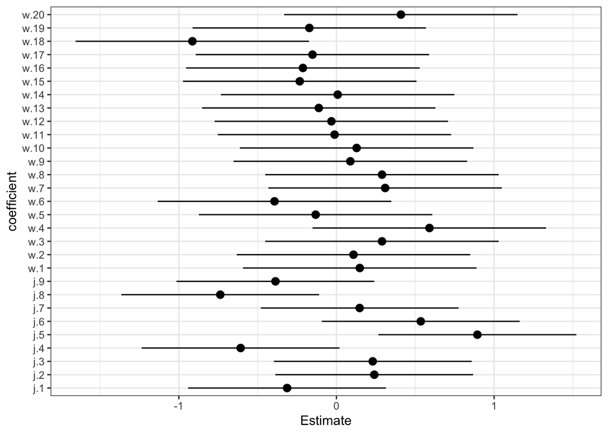

```r
m1.i.plot <- mi.i.df %>%
  mutate(est= factor(est, levels= c("j.1",  "j.2" , "j.3" , "j.4" , "j.5"  ,"j.6" , "j.7" , "j.8" , "j.9" , "w.1" , "w.2" , "w.3" , "w.4" , "w.5" , "w.6" , "w.7" ,"w.8" , "w.9"  ,"w.10" ,"w.11", "w.12" ,"w.13" ,"w.14", "w.15" ,"w.16", "w.17", "w.18", "w.19", "w.20"))) %>%
  ggplot() +
    geom_pointrange(aes(x = factor(est), y = mean, ymin = lower, ymax = upper), position = position_dodge(0.5)) +
    xlab("coefficient") +
    ylab("Estimate")+
  coord_flip()+
    theme_bw()

m1.i.plot
```

The a/j parameters are the judges. Each represents an average deviation of the scores. So judges with lower values are harsher on average. Judges with higher values liked the wines more on average. There is some noticeable variation here. It is fairly easy to tell the judges apart.

The w parameters are the wines. Each represents an average score across all judges. Except for wine 18 (a New Jersey red I think), there isn’t that much variation. These are good wines, after all. Overall, there is more variation from judge than from wine.

## 2.

Now consider three features of the wines and judges:

1. flight: Whether the wine is red or white.
2. wine.amer: Indicator variable for American wines.
3. judge.amer: Indicator variable for American judges.

Use indicator or index variables to model the influence of these features on the scores. Omit the individual judge and wine index variables from Problem 1. Do not include interaction effects yet. Again use ulam, justify your priors, and be sure to check the chains. What do you conclude about the differences among the wines and judges? Try to relate the results to the inferences in Problem 1.

The easiest way to code the data is to use indicator variables. Let’s look at that approach first. I’ll do an index variable version next. I’ll use the three indicator variables W (NJ wine), J (American NJ), and R (red wine).

## 2.a indicator variables

### 2.a rethinking

```r
dat_list2 <- list(
    S = standardize(d$score),
    W = d$wine.amer,
    J = d$judge.amer,
    F= if_else(d$flight == "white", 0, 1))

m2a <- ulam(
  alist(
    S ~ dnorm(mu, sigma),
    mu <- a + bW*W + bJ*J + bF*F,
    a ~ dnorm(0, 0.2),
    bW~ dnorm(0, 0.5),
    bJ~ dnorm(0, 0.5),
    bF~ dnorm(0, 0.5),
  sigma ~ dexp(1)
    ), data=dat_list2, chains=4 , cores=4)
```

```
## Trying to compile a simple C file
```

[output not shown]

```r
precis(m2a)
```

```
##              mean         sd        5.5%      94.5%    n_eff     Rhat4
## a     -0.01495630 0.12370093 -0.21861210 0.19285126 1383.242 1.0018744
## bW    -0.17661567 0.13708581 -0.39017766 0.04226162 1643.367 0.9991645
## bJ     0.22270033 0.13169594  0.02246812 0.43437208 1508.670 1.0003562
## bF    -0.00448245 0.14101873 -0.23814042 0.21548631 1763.548 0.9995173
## sigma  0.99748877 0.05099428  0.91907170 1.08128044 1786.144 1.0005360
```

```r
traceplot(m2a)
```

```
## [1] 1000
## [1] 1
## [1] 1000
```

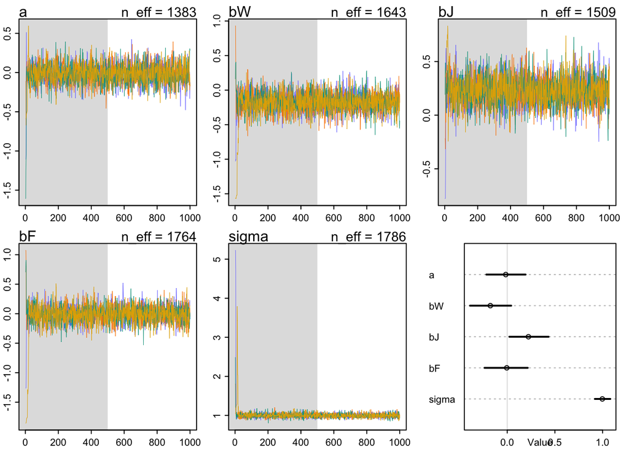

```r
plot(precis(m2a, 2))
```

### 2.a INLA

```r
d.i2a <- d %>%
  mutate(S = standardize(d$score),
    W = d$wine.amer,
    J = d$judge.amer,
    R= if_else(d$flight == "red", 1, 0))

m2a.i <- inla(S~W+J+R, data= d.i2a, control.fixed = list(
        mean= 0,
        prec= list(R=0.5, W=0.5, J= 0.5),
        mean.intercept= 0,
        prec.intercept= 0.2
),
control.compute = list(waic= TRUE))

summary(m2a.i)
```

```
##
## Call:
##    c("inla(formula = S ~ W + J + R, data = d.i2a, control.compute =
##    list(waic = TRUE), ", " control.fixed = list(mean = 0, prec = list(R =
##    0.5, W = 0.5, ", " J = 0.5), mean.intercept = 0, prec.intercept =
##    0.2))" )
## Time used:
##     Pre = 1.52, Running = 0.273, Post = 0.192, Total = 1.98
## Fixed effects:
##               mean    sd 0.025quant 0.5quant 0.975quant   mode kld
## (Intercept) -0.021 0.161     -0.336   -0.021      0.295 -0.021   0
## W           -0.190 0.150     -0.486   -0.190      0.106 -0.190   0
## J            0.246 0.148     -0.045    0.246      0.538  0.246   0
## R           -0.004 0.148     -0.294   -0.004      0.286 -0.004   0
##
## Model hyperparameters:
##                                         mean    sd 0.025quant 0.5quant
## Precision for the Gaussian observations 1.02 0.108      0.819     1.02
##                                         0.975quant mode
## Precision for the Gaussian observations       1.24 1.01
##
## Expected number of effective parameters(stdev): 3.96(0.004)
## Number of equivalent replicates : 45.42
##
## Watanabe-Akaike information criterion (WAIC) ...: 515.36
## Effective number of parameters .................: 4.79
##
## Marginal log-Likelihood:  -274.11
## Posterior marginals for the linear predictor and
##  the fitted values are computed
```

As expected, red and wines are on average the same—bR is right on top of zero. American judges seem to be more on average slightly more generous with ratings—bJ is slightly but reliably above zero. American wines have slightly lower average ratings than French wines—bW is mostly below zero, but not very large in absolute size.

## 2.b index variables

Okay, now for an index variable version. The thing about index variables is that you can easily end up with more parameters than in an equivalent indicator variable model. But it’s still the same posterior distribution. You can convert from one to the other (if the priors are also equivalent).

We’ll need three index variables: wid, jid, fid. Now wid is 1 for a French wine and 2 for a NJ wine,jid is 1 for a French judge and 2 for an American judge, and fid is 1 for red and 2 for white. Those 1L numbers are just the R way to type the number as an integer—“1L” is the integer 1, while “1” is the real number 1. We want integers for an index variable.

Now let’s think about priors for the parameters that correspond to each index value. Now the question isn’t how big the difference could be, but rather how far from the mean an indexed category could be. If we use Normal(0,0.5) priors, that would make a full standard deviation difference from the global mean rare. It will also match what we had above, in a crude sense. Again, I’d be tempted to something narrow, for the sake of regularization. But certainly something like Normal(0,10) is flat out silly, because it makes impossible values routine. Let’s see what we get:

### 2.b rethinking

```r
dat_list2b <- list(
    S = standardize(d$score),
    wid = d$wine.amer + 1,
    jid = d$judge.amer + 1,
    fid= if_else(d$flight=="red",1L,2L)
    )

m2b <- ulam(
  alist(
    S ~ dnorm(mu, sigma),
    mu <- w[wid]+j[jid]+f[fid],
    w[wid]~ dnorm(0, 0.5),
    j[wid]~ dnorm(0, 0.5),
    f[wid]~ dnorm(0, 0.5),
  sigma ~ dexp(1)
    ), data=dat_list2b, chains=4 , cores=4
  )
```

```
## Trying to compile a simple C file
```

[output not shown]

```r
precis(m2b, depth=2)
```

```
##               mean         sd       5.5%     94.5%     n_eff     Rhat4
## w[1]   0.097236423 0.29391374 -0.3653887 0.5810640  672.7720 1.0015118
## w[2]  -0.083976717 0.29084577 -0.5522101 0.3799421  667.5813 1.0001110
## j[1]  -0.123741069 0.29337562 -0.5928507 0.3483595  854.6675 0.9998646
## j[2]   0.117072193 0.29601075 -0.3388528 0.5798940  872.5379 1.0000707
## f[1]  -0.004525041 0.29454190 -0.4838633 0.4512032  951.5356 1.0011091
## f[2]   0.002561441 0.29438513 -0.4733889 0.4733968  960.4014 1.0015796
## sigma  0.998674596 0.05566912  0.9121807 1.0923460 1376.0241 0.9998385
```

To see that this model is the same as the previous, let’s compute contrasts. The contrast between American and French wines is:

```r
post <- extract.samples(m2b)
diff_w <- post$w[,2] - post$w[,1]
precis( diff_w )
```

```
##              mean        sd     5.5%      94.5%   histogram
## diff_w -0.1812131 0.1430014 -0.41065 0.04510847 ▁▁▁▃▇▇▅▂▁▁▁
```

That’s almost exactly the same mean and standard deviation as bW in the first model. The other contrasts match as well.

Something to notice about the two models is that the second one does sample less efficiently. The n_eff values are lower. This isn’t a problem, but it is a consequence of the higher correlations in the posterior, a result of the redundant parameterization. If you look at the pairs(m2b) plot, you’ll see tight correlations for each pair of index parameters of the same type. This is because really it is a difference that matters, and many combinations of two numbers can produce the same difference. But the priors keep this from ruining our inference. if you tried the same thing without priors, it would likely fall apart and return very large standard errors.

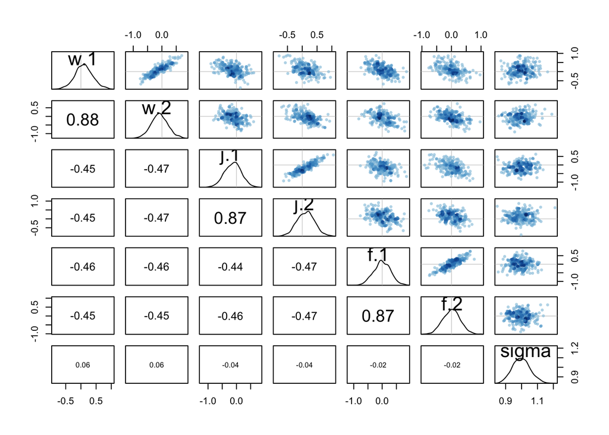

```r
pairs(m2b)
```

### 2.b INLA

Note that here we have used the selection argument to keep just the sampled values of the coefficients of wine.amer.no and wine.amer.yes. Note that the expression wine.amer.no = 1 means that we want to keep the first element in effect wine.amer.no. Note that in this case there is only a single value associated with wine.amer.no (i.e., the coefficient) but this can be extended to other latent random effects with possibly more values.

The object returned by inla.posterior.sample() is a list of length 100, where each element contains the samples of the different effects in the model in a name list.

```r
d.i2b <- d %>%
  mutate(S = standardize(d$score),
   wine.amer.no= na_if(if_else(wine.amer==0, 1, 0), 0),
         wine.amer.yes= na_if(wine.amer, 0),
         judge.amer.no= na_if(if_else(judge.amer==0, 1, 0), 0),
         judge.amer.yes= na_if(judge.amer, 0),
         f.red= na_if(if_else(flight=="red", 1, 0), 0),
   f.white= na_if(if_else(flight=="white", 1, 0), 0)
         )


m2b.i<- inla(S~ -1 + wine.amer.no + wine.amer.yes + judge.amer.no+ judge.amer.yes + f.red + f.white, data= d.i2b,
                        control.fixed = list(
        mean= 0,
        prec= 0.5),
        control.compute = list(
          dic=TRUE, waic= TRUE, config=TRUE)
)

summary(m2b.i )
```

```
##
## Call:
##    c("inla(formula = S ~ -1 + wine.amer.no + wine.amer.yes + judge.amer.no
##    + ", " judge.amer.yes + f.red + f.white, data = d.i2b, control.compute
##    = list(dic = TRUE, ", " waic = TRUE, config = TRUE), control.fixed =
##    list(mean = 0, ", " prec = 0.5))")
## Time used:
##     Pre = 1.57, Running = 0.247, Post = 0.264, Total = 2.08
## Fixed effects:
##                  mean    sd 0.025quant 0.5quant 0.975quant   mode kld
## wine.amer.no    0.097 0.821     -1.514    0.097      1.707  0.097   0
## wine.amer.yes  -0.094 0.820     -1.703   -0.094      1.515 -0.094   0
## judge.amer.no  -0.122 0.821     -1.733   -0.122      1.488 -0.122   0
## judge.amer.yes  0.126 0.820     -1.484    0.126      1.734  0.126   0
## f.red           0.000 0.820     -1.611    0.000      1.609  0.000   0
## f.white         0.004 0.820     -1.607    0.004      1.613  0.004   0
##
## Model hyperparameters:
##                                         mean    sd 0.025quant 0.5quant
## Precision for the Gaussian observations 1.02 0.108      0.819     1.02
##                                         0.975quant mode
## Precision for the Gaussian observations       1.24 1.01
##
## Expected number of effective parameters(stdev): 3.98(0.002)
## Number of equivalent replicates : 45.20
##
## Deviance Information Criterion (DIC) ...............: 515.53
## Deviance Information Criterion (DIC, saturated) ....: 188.15
## Effective number of parameters .....................: 5.07
##
## Watanabe-Akaike information criterion (WAIC) ...: 515.40
## Effective number of parameters .................: 4.81
##
## Marginal log-Likelihood:  -274.88
## Posterior marginals for the linear predictor and
##  the fitted values are computed
```

```r
## Pull out summaries from the model object
m2b.i.sum <- summary(m2b.i)

m2b.i.samp <- inla.posterior.sample(100, m2b.i , selection = list(wine.amer.no = 1, wine.amer.yes = 1))

m2b.i.contrast <- inla.posterior.sample.eval(function(...) {wine.amer.yes - wine.amer.no},
   m2b.i.samp)
summary(as.vector(m2b.i.contrast))
```

```
##     Min.  1st Qu.   Median     Mean  3rd Qu.     Max.
## -0.56968 -0.28892 -0.13332 -0.16244 -0.06152  0.33648
```

# 3.

Now consider two-way interactions among the three features.You should end up with three different interaction terms in your model. These will be easier to build, if you use indicator variables. Again use ulam, justify your priors, and be sure to check the chains. Explain what each interaction means. Be sure to interpret the model’s predictions on the outcome scale (mu, the expected score), not on the scale of individual parameters. You can use link to help with this, or just use your knowledge of the linear model instead. What do you conclude about the features and the scores? Can you relate the results of your model(s) to the individual judge and wine inferences from Problem 1?

## 3.a indicator variables

### 3.a rethinking

For the indicator approach, we can use the same predictor variables as before, it’s the model that’s different. I used the same priors as before for the main effects. I used tighter priors for the interactions. Why? Because interactions represent sub-categories of data, and if we keep slicing up the sample, differences can’t keep getting bigger. Again, the most important thing is not to use flat priors like Nor- mal(0,10) that produce impossible outcomes.

```r
dat_list2 <- list(
    S = standardize(d$score),
    W = d$wine.amer,
    J = d$judge.amer,
    R= if_else(d$flight == "red", 1, 0))

m3a <- ulam(
  alist(
    S ~ dnorm(mu, sigma),
    mu <- a + bW*W + bJ*J + bR*R +
      bWJ*W*J + bWR*W*R + bJR*J*R,
    a ~ dnorm(0, 0.2),
   c(bW,bJ,bR) ~ dnorm(0,0.5),
    c(bWJ,bWR,bJR) ~ dnorm(0,0.25),
  sigma ~ dexp(1)
    ), data=dat_list2, chains=4 , cores=4)
```

```
## Trying to compile a simple C file
```

[output not shown]

```r
precis(m3a)
```

```
##              mean         sd        5.5%     94.5%     n_eff     Rhat4
## a     -0.03678903 0.13311217 -0.24508768 0.1790197  819.4361 1.0030511
## bR     0.07316014 0.18112583 -0.21452007 0.3680318 1099.0314 1.0033066
## bJ     0.20586911 0.17755342 -0.06997461 0.4963030 1277.7180 0.9997645
## bW    -0.08255132 0.17997632 -0.37857073 0.1989869 1079.4479 1.0035388
## bJR    0.05321820 0.18407706 -0.23538327 0.3486554 1624.7912 0.9998535
## bWR   -0.21374006 0.18540219 -0.50707268 0.0868323 1447.2050 1.0026455
## bWJ   -0.02266668 0.18307865 -0.32034379 0.2735765 1333.2534 1.0015270
## sigma  0.99601406 0.05366004  0.91404124 1.0836386 2552.2307 0.9986655
```

Reading the parameters this way is not easy. But right away you might notice that bW is now close to zero and overlaps it a lot on both sides. NJ wines are no longer on average worse. So the interactions did something. Glancing at the interaction parameters, you can see that only one of them has much mass away from zero, bWR, the interaction between NJ wines and red flight, so red NJ wines. To get the predicted scores for red and white wines from both NJ and France, for both types of judges, we can use link:

[figure not shown]

```r
pred_dat <- data.frame(
    W = rep( 0:1 , times=4 ),
    J = rep( 0:1 , each=4 ),
    R = rep( c(0,0,1,1) , times=2 )
)
mu <- link( m3a )

row_labels <- paste( ifelse(pred_dat$W==1,"A","F") ,
                 ifelse(pred_dat$J==1,"A","F") ,
                 ifelse(pred_dat$R==1,"R","W") , sep="" )
plot( precis( list(mu=mu) , 2 ) , labels=row_labels )
```